# Can I get a Credit Card?: How Different Variables Affect the Acceptance of a Credit Card Applications

S&DS 230 Final Project

## **1. Introduction**

As students exploring R while also studying economics, we wanted to combine the two disciplines for our final project. In addition, having turned 18/19 ourselves in the past few years, we are now eligible to own credit cards under our own names, so we thought it would be interesting to see what factors affect the acceptance of a credit card application. In this project, we specifically look at the relationship between credit card application acceptance and variables such as average monthly credit card expenditure, the age of the applicant, their yearly income, the number of dependents they have, whether they own a home or not, the number of months living at their current address, the number of active credit card accounts they have, and the number of major credit cards they hold. We hope that through this analysis, we gain a better understanding of how credit cards work for our future financial endeavors.

## **2. Data**

### List of Variables

Categorical Variables:

- card: acceptance of credit card application
  - 1/yes if application is accepted, 0/no if it is not accepted
- owner: whether applicant owns or rents their home
  - 1/yes if they are a homeowner, 0/no if they rent

Continuous Variables:

- reports: number of major derogatory reports filed against them
- age: n years plus twelfths of a year
- income: yearly income in tens of thousands of dollars
- dependents: number of dependents
- expenditure: average monthly credit card expenditure in dollars
- months: number of months living at their current address
- active: the number of active credit card accounts
- majorcards: the number of major credit cards

Data from: [Link to Data](https://www.kaggle.com/dansbecker/aer-credit-card-data?fbclid=IwAR1VYOAH8a2vI52pUHdnr16f8-8HQFWbUJ1Nc2D1jRgbb8zxCQUrymprGGk)

## **3. Data Cleaning**

```r
setwd("~/Downloads/")
df <- read.csv("AER_credit_card_data.csv")
dim(df)
```

```
## [1] 1319   12
```

```r
head(df)
```

```
##   card reports      age income       share expenditure owner selfemp dependents
## 1  yes       0 37.66667 4.5200 0.033269910  124.983300   yes      no          3
## 2  yes       0 33.25000 2.4200 0.005216942    9.854167    no      no          3
## 3  yes       0 33.66667 4.5000 0.004155556   15.000000   yes      no          4
## 4  yes       0 30.50000 2.5400 0.065213780  137.869200    no      no          0
## 5  yes       0 32.16667 9.7867 0.067050590  546.503300   yes      no          2
## 6  yes       0 23.25000 2.5000 0.044438400   91.996670    no      no          0
##   months majorcards active
## 1     54          1     12
## 2     34          1     13
## 3     58          1      5
## 4     25          1      7
## 5     64          1      5
## 6     54          1      1
```

```r
names(df)
```

```
##  [1] "card"        "reports"     "age"         "income"      "share"
##  [6] "expenditure" "owner"       "selfemp"     "dependents"  "months"
## [11] "majorcards"  "active"
```

```r
##data cleaning
df$age <- floor(df$age)
df$age[df$age < 18] <- NA
df <- df[complete.cases(df),]
dim(df)
```

```
## [1] 1312   12
```

```r
head(df)
```

```
##   card reports age income       share expenditure owner selfemp dependents
## 1  yes       0  37 4.5200 0.033269910  124.983300   yes      no          3
## 2  yes       0  33 2.4200 0.005216942    9.854167    no      no          3
## 3  yes       0  33 4.5000 0.004155556   15.000000   yes      no          4
## 4  yes       0  30 2.5400 0.065213780  137.869200    no      no          0
## 5  yes       0  32 9.7867 0.067050590  546.503300   yes      no          2
## 6  yes       0  23 2.5000 0.044438400   91.996670    no      no          0
##   months majorcards active
## 1     54          1     12
## 2     34          1     13
## 3     58          1      5
## 4     25          1      7
## 5     64          1      5
## 6     54          1      1
```

*After reading the data, we first looked at the dimensions, the first 6 rows, and the names of rows. We noticed that the “age” variable was not in whole numbers, and it also included ages under 18 (which means that the applicant cannot own a credit card under their name OR that the response on the survey was wrong), so we took the floor of age and deleted the cases where age was under 18. There was not a lot of data cleaning to do for the other variables.*

## **4. Graphics**

### Boxplots and Histograms:

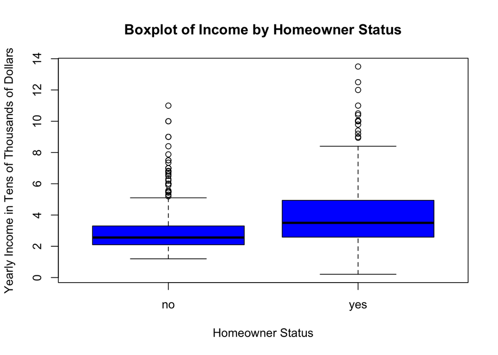

```r
boxplot(df$income ~ df$owner, main = "Boxplot of Income by Homeowner Status", xlab = "Homeowner Status", ylab = "Yearly Income in Tens of Thousands of Dollars", col = "blue")
```

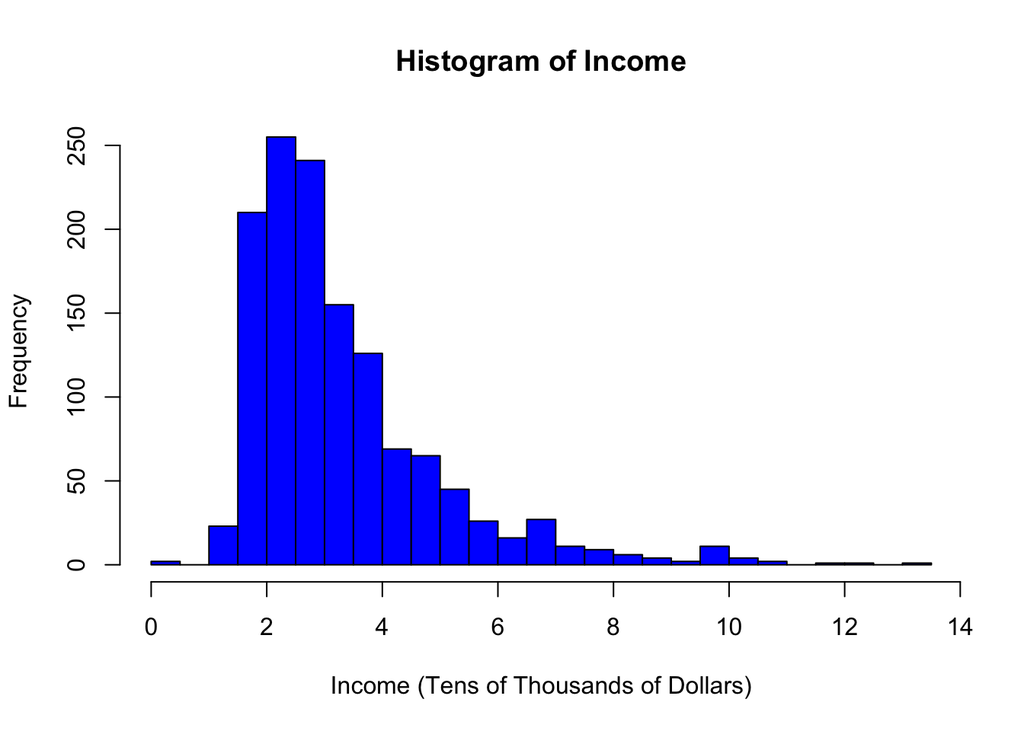

```r
hist(df$income, xlab = "Income (Tens of Thousands of Dollars)", main = "Histogram of Income", col = "blue", breaks = 25)
```

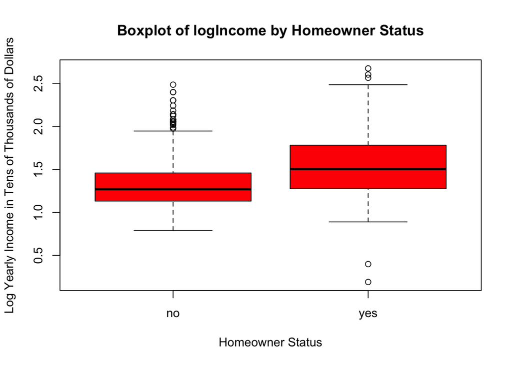

```r
df$logincome <- log(df$income + 1)
boxplot(df$logincome ~ df$owner, main = "Boxplot of logIncome by Homeowner Status", xlab = "Homeowner Status", ylab = "Log Yearly Income in Tens of Thousands of Dollars", col = "red")
```

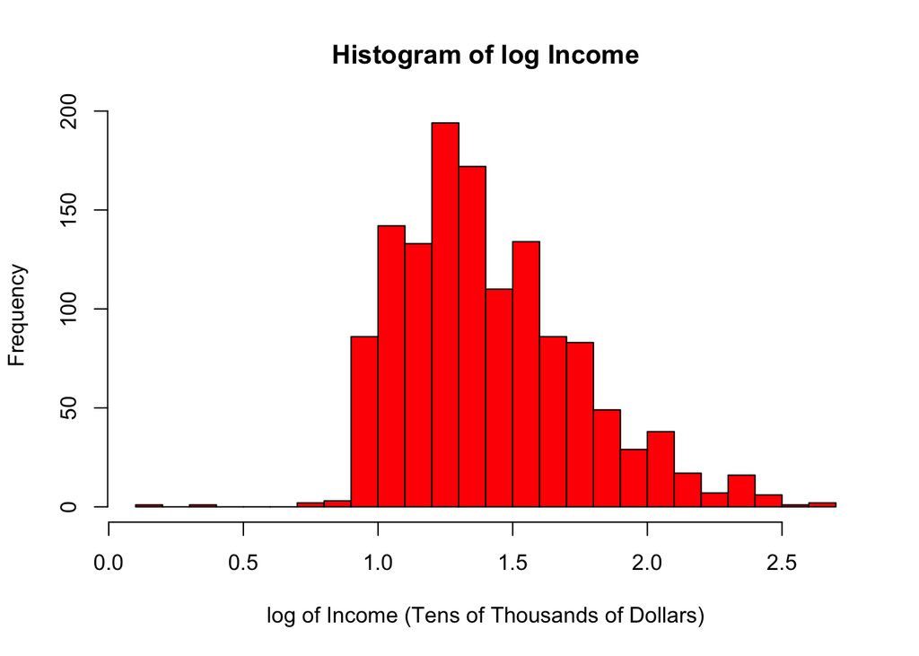

```r
hist(df$logincome, xlab = "log of Income (Tens of Thousands of Dollars)", main = "Histogram of log Income", col = "Red", breaks = 25)
```

*The first boxplot shows that the median yearly income for homeowners is higher than that of non-homeowners (renters), which means that homeowners have on average higher yearly income. There are many outliers for both homeowners and renters. The first histogram shows us that the distribution of income is heavily right skewed, indicating that more people tend to have incomes that bunch around the lower end. We decided to take the log of income and make a boxplot and histogram. Here, the boxplot after transformation reveals that the log of median yearly income for homeowners is higher than that of renters, and there are fewer outliers. The histogram shows us that the distribution of log of income is still right skewed, but not as skewed as before the transformation.*

### Scatterplot:

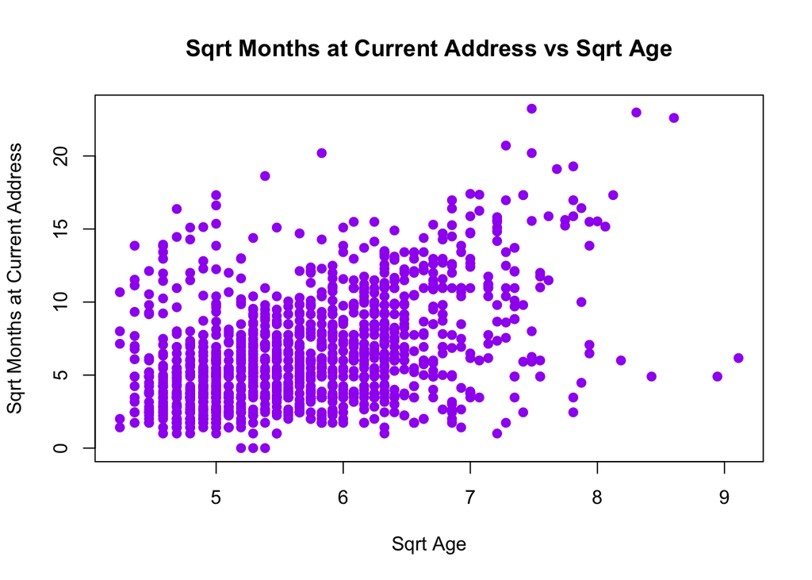

```r
df$sqrtage <- sqrt(df$age)
df$sqrtmonths <- sqrt(df$months)
plot(df$sqrtage, df$sqrtmonths, main = "Sqrt Months at Current Address vs Sqrt Age", xlab = "Sqrt Age", ylab = "Sqrt Months at Current Address", col = "purple", pch = 19)
```

*We took the square root of both age and months because before the transformation, our plot did not appear to have a linear trend, which would be inappropriate for calculating correlation. After this transformation, there appears to be a relatively moderately positive correlation between square root age and square root months at current address. It appears that using the correlation function is appropriate now since there are no strong outliers that may be over influencing the correlations.*

#### Note: Normal quantile plot and residual plots can be found in the multiple regression section

## **5. Basic Tests**

### Correlation

```r
cor(df$sqrtage, df$sqrtmonths)
```

```
## [1] 0.4488386
```

```r
cor.test(df$sqrtage, df$sqrtmonths)
```

```
##
##  Pearson's product-moment correlation
##
## data:  df$sqrtage and df$sqrtmonths
## t = 18.179, df = 1310, p-value < 2.2e-16
## alternative hypothesis: true correlation is not equal to 0
## 95 percent confidence interval:
##  0.4045459 0.4910305
## sample estimates:
##       cor
## 0.4488386
```

*The correlation between square root age and square root months at current address is positive and relatively moderately strong at 0.4488386, as the above scatterplot shows. Using a correlation test, the p-value is less than our alpha of .05 so we reject the null hypothesis that the correlation is 0, which means there is a significantly non-zero correlation.*

### Bootstrap Confidence Interval for Correlation:

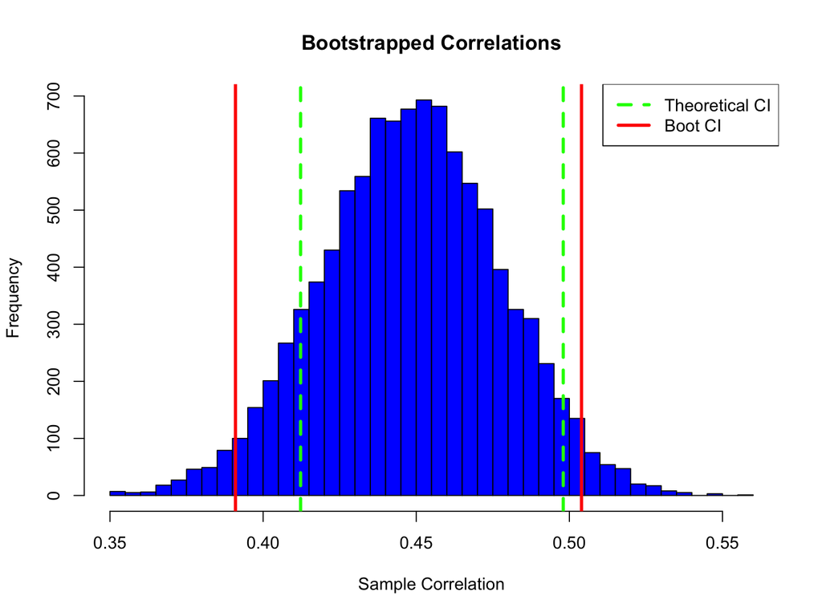

```r
N <- nrow(df)
n_samp <- 10000
corResults <- rep(NA, n_samp)

for(i in 1:n_samp){
  s <- sample(1:N, N , replace = T)
  fakeData <- df[s, ]
  corResults[i] <- cor(fakeData$sqrtage, fakeData$sqrtmonths)
}

ci_r <- quantile(corResults, c(.025, .975))

hist(corResults, col = "blue", main = "Bootstrapped Correlations", xlab = "Sample Correlation", breaks = 50)
abline(v = ci_r, lwd = 3, col = "red")
abline(v = cor.test(df$age, df$months)$conf.int, lwd = 3, col = "green", lty = 2)
legend("topright", c("Theoretical CI","Boot CI"), lwd = 3, col = c("green","red"), lty = c(2, 1))
```

*Since our bootstrapped confidence interval does not include 0, we reject the null hypothesis and conclude that the correlation between square root age and square root months at current address is significantly non-zero. The bootstrapped confidence interval is considerably wider than the theoretical confidence interval, which indicates that there is less certainty with our bootstrapped interval.*

## T-Test:

```r
t.test(df$expenditure ~ df$owner)
```

```
##
##  Welch Two Sample t-test
##
## data:  df$expenditure by df$owner
## t = -3.2796, df = 1152.3, p-value = 0.00107
## alternative hypothesis: true difference in means is not equal to 0
## 95 percent confidence interval:
##  -80.45405 -20.22400
## sample estimates:
##  mean in group no mean in group yes
##          162.7552          213.0942
```

*The p-value of 0.00107 is less than alpha level of 0.05, which means we reject the null hypothesis and there is a statistically significant difference in means of average monthly credit card expenditure between people who own their home and people who rent. We are 95% confident that the true difference in means between renters and homeowners is between -$20.22400 and -$80.45405 (avg monthly credit card expenditures).*

## **Permutation Test**

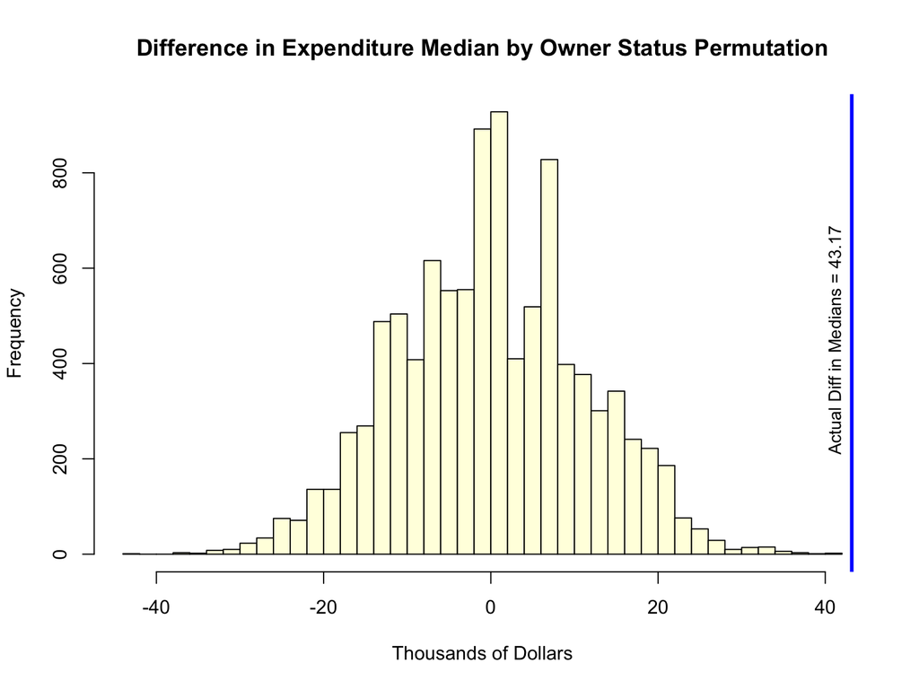

```r
actualdiff <- median(df$expenditure[df$owner == "yes"]) -  median(df$expenditure[df$owner == "no"])

set.seed(1)
N <- 10000

diffvals <- rep(NA, N)
for (i in 1:N) {
  fakeOwner <- sample(df$owner)
  diffvals[i] <- median(df$expenditure[fakeOwner == "yes"]) -  median(df$expenditure[fakeOwner == "no"])
}

hist(diffvals, col = "lightyellow", main = "Difference in Expenditure Median by Owner Status Permutation", xlab = "Thousands of Dollars", breaks = 50)
abline(v = actualdiff, col="blue", lwd=3)
text(actualdiff - 2, 450, paste("Actual Diff in Medians =", round(actualdiff,2)), srt = 90, cex = .9)
```

```r
mean(abs(diffvals) >= abs(actualdiff))
```

```
## [1] 1e-04
```

*Since the p-value of finding the actual difference in our permutation test (0.0001) is less than our alpha of .05, we can reject the null hypothesis that there is no difference in the median of average credit card expenditure per month by owner status.*

## **6. Multiple Regression**

### Description of Plan:

*Through backwards stepwise multiple regression, we aim to predict log average credit card expenditure per month through other continuous variables (including transformations of age, income, dependents, active, and months). We will only analyze the data points in which expenditure is greater than 0 (ie. people who are regularly actually spending money on their credit cards). We excluded share (which is just expenditure / income) and reports, which appears to be too heavily right skewed with too many 0 data points. In addition, we excluded majorcards, which acts similarly to a categorical variable, as the below histogram shows.*

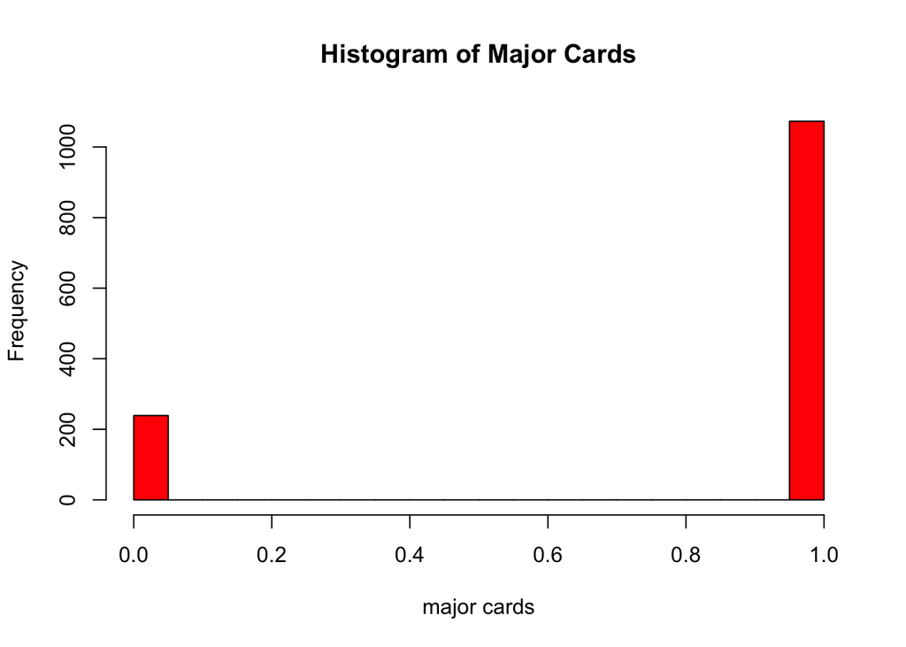

```r
hist(df$majorcards, xlab = "major cards", main = "Histogram of Major Cards", col = "Red", breaks = 25)
```

### Results, Residual Plots, and Discussion

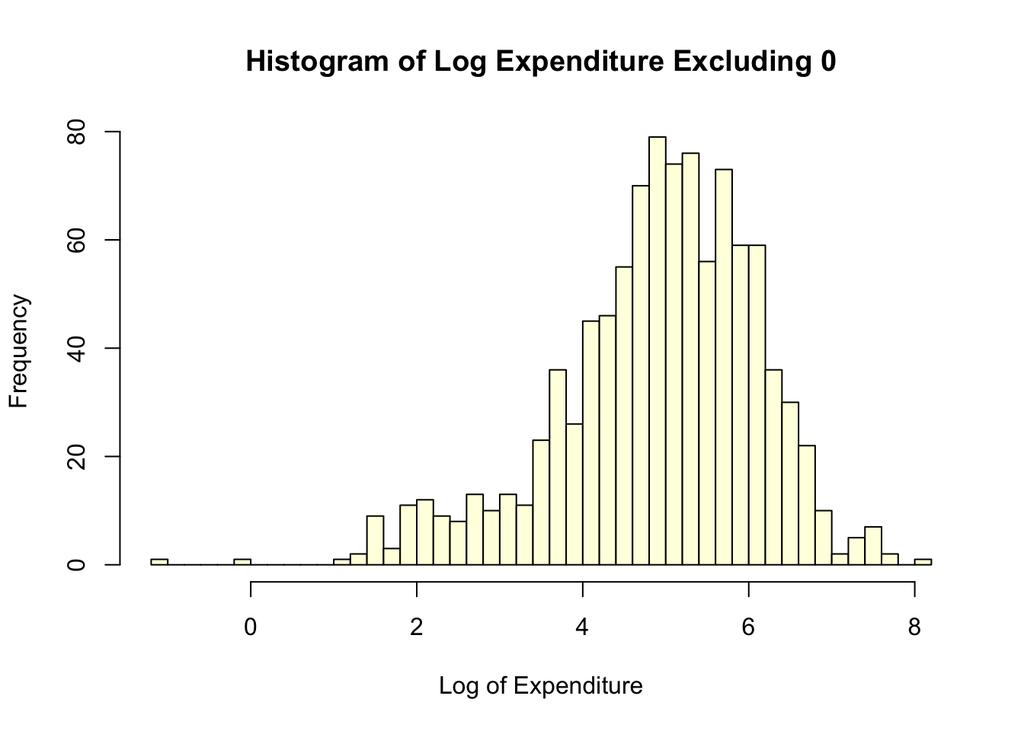

```r
df1 <- df[df$expenditure > 0,]
df1$logexpenditure <- log(df1$expenditure)
df1$sqrtactive <- sqrt(df1$active)
df1 <- df1[,c("logexpenditure", "sqrtage", "logincome", "dependents", "sqrtactive", "sqrtmonths")]

hist(df1$logexpenditure, main = "Histogram of Log Expenditure Excluding 0", xlab = "Log of Expenditure", col = "lightyellow", breaks = 50)
```

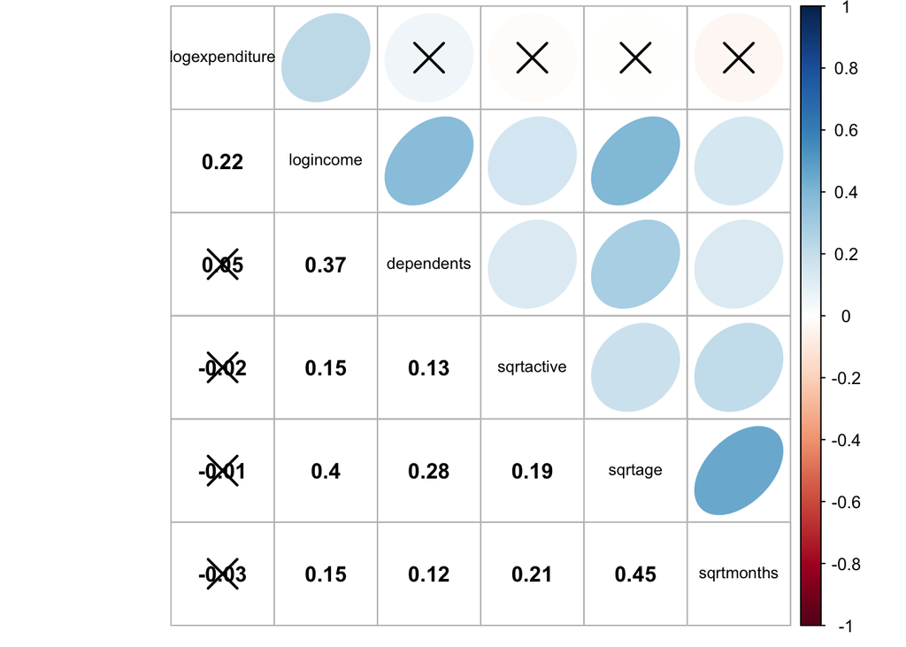

```r
sigcorr <- cor.mtest(df1, conf.level = .95)
corrplot.mixed(cor(df1), lower.col = "black", upper = "ellipse", tl.col = "black", order = "hclust", p.mat = sigcorr$p, sig.level = .05, tl.cex = .75)
```

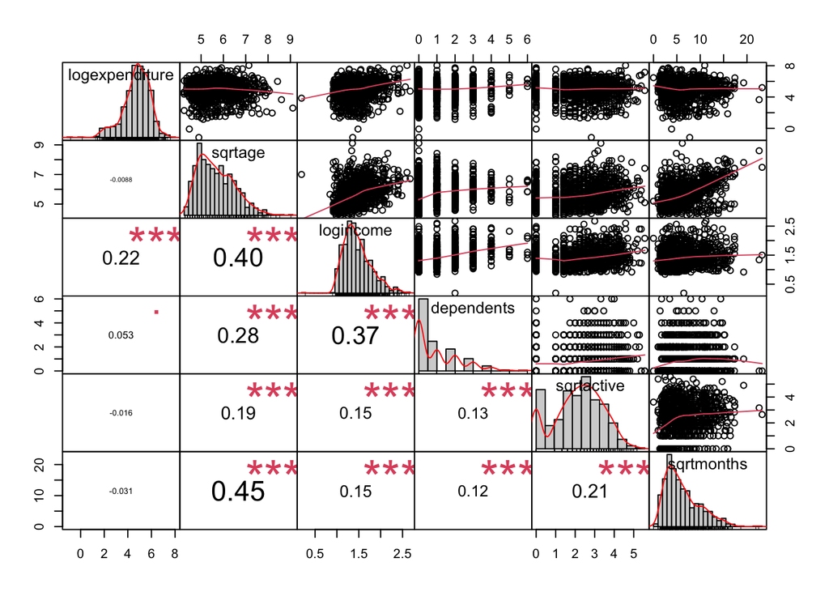

```r
pairsJDRS(df1)
```

```r
# Final model after manual backwards stepwise regression
mod2 <- lm(logexpenditure ~ sqrtage + logincome, data = df1)
summary(mod2)
```

```
##
## Call:
## lm(formula = logexpenditure ~ sqrtage + logincome, data = df1)
##
## Residuals:
##     Min      1Q  Median      3Q     Max
## -6.1294 -0.5748  0.1518  0.8260  2.7643
##
## Coefficients:
##             Estimate Std. Error t value Pr(>|t|)
## (Intercept)  4.44763    0.27059  16.437  < 2e-16 ***
## sqrtage     -0.17337    0.04985  -3.478 0.000527 ***
## logincome    1.00515    0.12458   8.068 2.05e-15 ***
## ---
## Signif. codes:  0 '***' 0.001 '**' 0.01 '*' 0.05 '.' 0.1 ' ' 1
##
## Residual standard error: 1.184 on 993 degrees of freedom
## Multiple R-squared:  0.0616, Adjusted R-squared:  0.05971
## F-statistic: 32.59 on 2 and 993 DF,  p-value: 1.957e-14
```

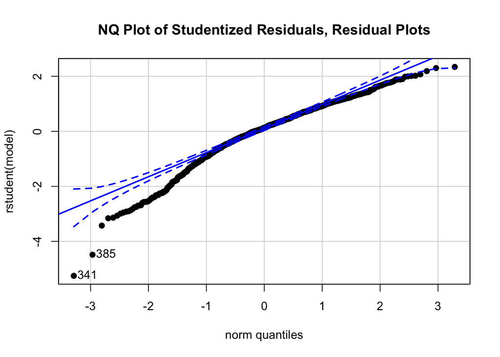

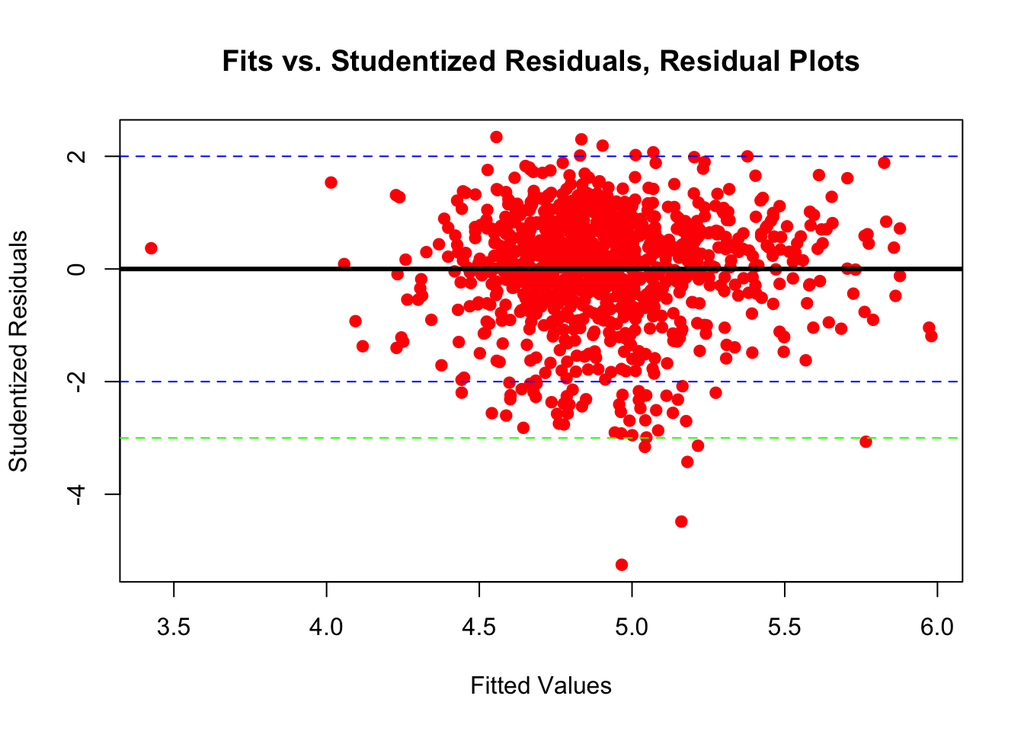

```r
myResPlots2(mod2)
```

## **7. Logistic Regression**

```r
df2 <- df
df2$card[df2$card == "yes"] <- 1
df2$card[df2$card == "no"] <- 0
df2$card <- as.factor(df2$card)
l1 <- glm(card ~ owner, data = df2, family = binomial)
summary(l1)
```

```
##
## Call:
## glm(formula = card ~ owner, family = binomial, data = df2)
##
## Deviance Residuals:
##     Min       1Q   Median       3Q      Max
## -1.9295   0.5813   0.5813   0.8100   0.8100
##
## Coefficients:
##             Estimate Std. Error z value Pr(>|z|)
## (Intercept)  0.94609    0.08229  11.497  < 2e-16 ***
## owneryes     0.74647    0.14117   5.288 1.24e-07 ***
## ---
## Signif. codes:  0 '***' 0.001 '**' 0.01 '*' 0.05 '.' 0.1 ' ' 1
##
## (Dispersion parameter for binomial family taken to be 1)
##
##     Null deviance: 1398.5  on 1311  degrees of freedom
## Residual deviance: 1369.1  on 1310  degrees of freedom
## AIC: 1373.1
##
## Number of Fisher Scoring iterations: 4
```

```r
odds.ratio(l1)
```

```
##                 OR  2.5 % 97.5 %         p
## (Intercept) 2.5756 2.1960 3.0325 < 2.2e-16 ***
## owneryes    2.1095 1.6043 2.7916 1.238e-07 ***
## ---
## Signif. codes:  0 '***' 0.001 '**' 0.01 '*' 0.05 '.' 0.1 ' ' 1
```

## **8. ANOVA**

*For ANOVA, we decided to split the ages into three groups: 18-30, 31-49, and 50+ to compare the income between the three groups*

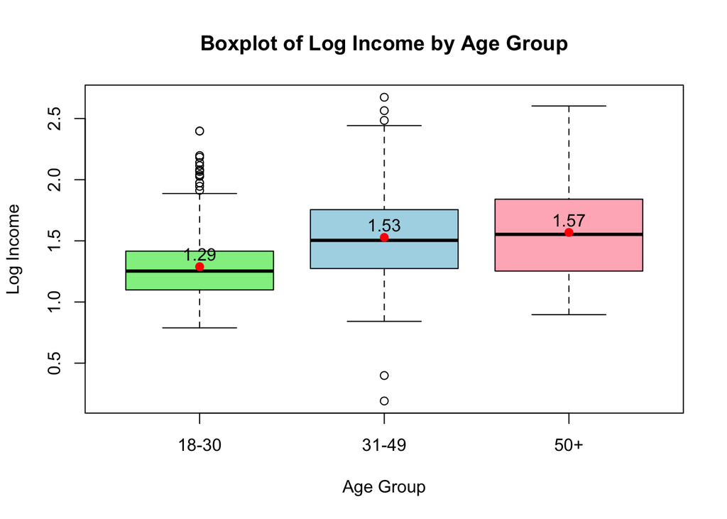

```r
df3 <- df
df3$agegroup <- rep(NA, nrow(df3))
df3$agegroup[df3$age %in% seq(18, 30)] <- "18-30"
df3$agegroup[df3$age %in% seq(31, 49)] <- "31-49"
df3$agegroup[df3$age >= 50] <- "50+"

boxplot(df3$logincome ~ df3$agegroup, main = "Boxplot of Log Income by Age Group", col = c("lightgreen", "lightblue", "lightpink"), xlab = "Age Group", ylab = "Log Income")
means <- tapply(df3$logincome, df3$agegroup, mean)
points(means, col = "red", pch = 19)
text(x = 1:3, y = means + .1, labels = round(means,2))
```

```r
sds <- tapply(df3$logincome, df3$agegroup, sd)
max(sds) / min(sds)
```

```
## [1] 1.632291
```

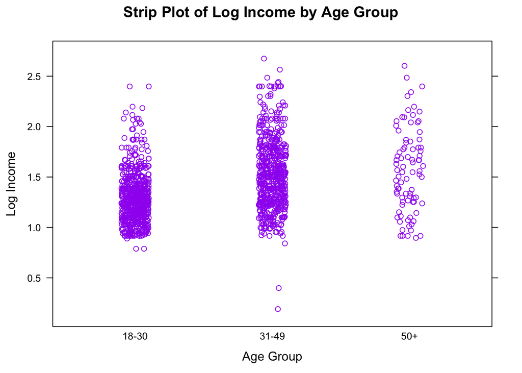

```r
stripplot(df3$logincome ~ df3$agegroup, jitter = .1, main = "Strip Plot of Log Income by Age Group", col = "purple", xlab = "Age Group", ylab = "Log Income")
```

```r
aov1 <- aov(df3$logincome ~ df3$agegroup)
summary(aov1)
```

```
##                Df Sum Sq Mean Sq F value Pr(>F)
## df3$agegroup    2  19.76   9.880   104.2 <2e-16 ***
## Residuals    1309 124.08   0.095
## ---
## Signif. codes:  0 '***' 0.001 '**' 0.01 '*' 0.05 '.' 0.1 ' ' 1
```

```r
mod1 <- lm(df3$logincome ~ df3$agegroup)
summary(mod1)
```

```
##
## Call:
## lm(formula = df3$logincome ~ df3$agegroup)
##
## Residuals:
##      Min       1Q   Median       3Q      Max
## -1.33764 -0.20844 -0.02864  0.17649  1.14589
##
## Coefficients:
##                   Estimate Std. Error t value Pr(>|t|)
## (Intercept)        1.28875    0.01218 105.813  < 2e-16 ***
## df3$agegroup31-49  0.23952    0.01760  13.608  < 2e-16 ***
## df3$agegroup50+    0.28045    0.03536   7.931 4.64e-15 ***
## ---
## Signif. codes:  0 '***' 0.001 '**' 0.01 '*' 0.05 '.' 0.1 ' ' 1
##
## Residual standard error: 0.3079 on 1309 degrees of freedom
## Multiple R-squared:  0.1374, Adjusted R-squared:  0.1361
## F-statistic: 104.2 on 2 and 1309 DF,  p-value: < 2.2e-16
```

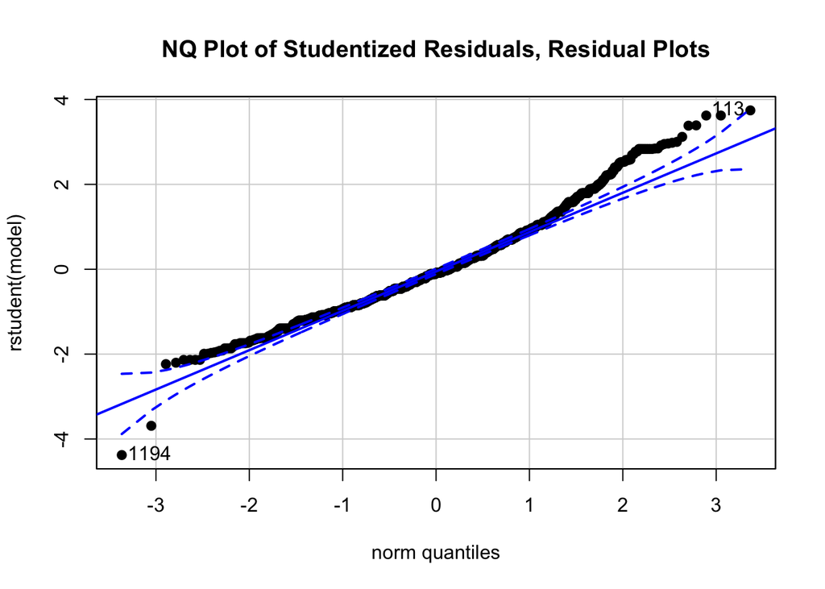

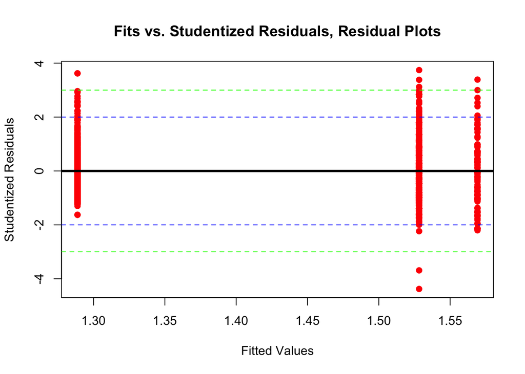

```r
myResPlots2(aov1)
```

```r
(tukey1 <- TukeyHSD(aov1))
```

```
##   Tukey multiple comparisons of means
##     95% family-wise confidence level
##
## Fit: aov(formula = df3$logincome ~ df3$agegroup)
##
## $`df3$agegroup`
##                   diff         lwr       upr     p adj
## 31-49-18-30 0.23951633  0.19821627 0.2808164 0.0000000
## 50+-18-30   0.28044904  0.19747462 0.3634235 0.0000000
## 50+-31-49   0.04093271 -0.04247652 0.1243419 0.4825935
```

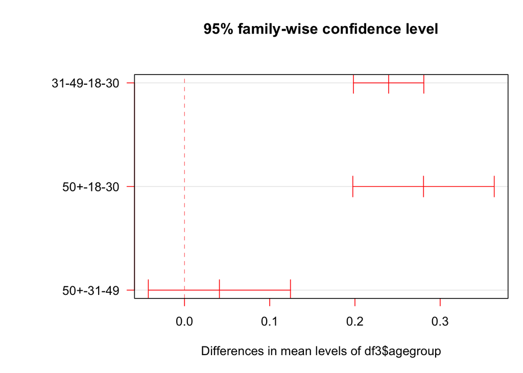

```r
par(mar = c(5, 9, 5, 1))
plot(tukey1, las = 1, col = "red")
```

## **9. Conclusions and Summary**

*Throughout our analysis, we were able to find interesting relationship between the variables in our data. Looking at our graphics, we are able to make some initial inferences and see that homeowners tend to have higher incomes than non-homeowners, more people tend to have incomes on the lower end, and that there is generally a relatively positive correlation between square root age and square root months at current address. We were then able to calculate the correlation of sqrt age and sqrt months and use a correlation test to confirm that it is significantly non-zero. Our Bootstrap confidence interval also comes to the same conclusion. Our t-test then shows that there is a statistically significant difference in the means of credit card expenditure based on whether or not someone owns a home. Our permutation test comes to the same conclusion except instead of mean expenditure, we tested for median expenditure and found that it was statistically significantly different based on whether or not someone is a homeowner. Through multiple regression, we found that square root age and log income are significant predictors of credit card expenditure. Through logistic regression, we found that home ownership is a significant predictor of whether or not your credit card is approved with those owning their homes being more likely to be approved. We also used ANOVA to look at income between three age grous, and concluded that there was a statistically significant difference in means between our three age groups. Altogether, we gained various insights about credit card activity that we will be able to convert to practical knowledge as beginner credit card holders ourselves.*